# Conceptual Model Coverage in School Meal Literature

## Conceptual Model Overview

Below is the simplified conceptual model guiding this synthesis.

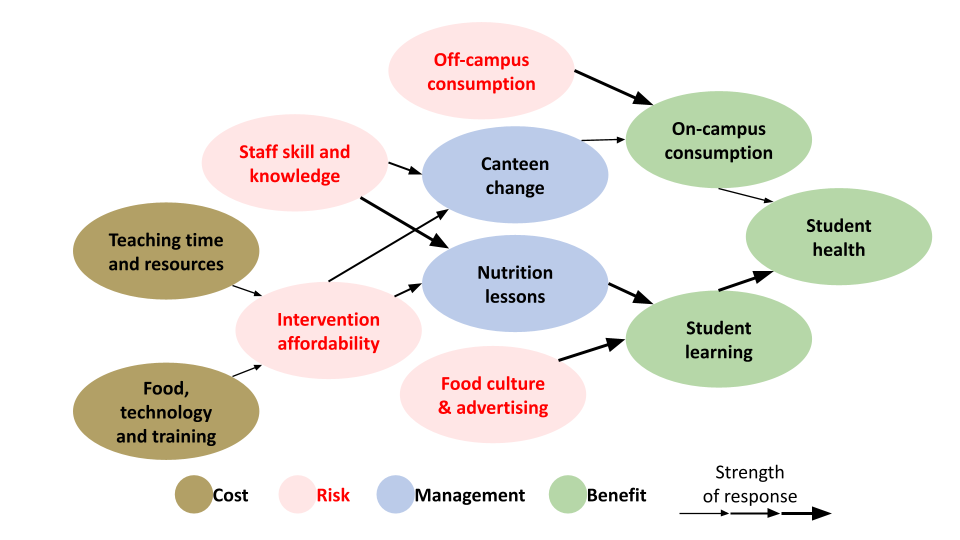

Conceptual Model

## Search Scope and Methodology

The original search query was:

> (“school nutrition” OR “school meal”) AND (policy OR implementation OR intervention) AND (“primary school” OR “elementary school”)

This query was used to identify papers relevant to the domains shown in the conceptual model above. We shared all the results and our annotations to a .bib file.

```r
bib <- read.bib("bib/HUPH_Kim Anh.bib")
bib_texts <- sapply(bib, function(x) paste(x$title, x$abstract, x$annote, collapse = " "))
```

To assess alignment of each component of the model with literature evidence, we conducted keyword-based searches within a BibTeX file containing 53 sources.

## Coverage of Model Components

We explored the following components using targeted sub-queries.

### 1. Canteen Change

`canteen, cafeteria` Common institutional meal locations `meal service, meal program, etc.` Covers provision models `school meal, school lunch, school food` Typical descriptors `school feeding` Often used in development contexts `food environment` Broader contextual term `on-campus consumption` Links to food access location `meal access` Policy/accessibility framing `school dining` Used in some UK/European contexts

```r
canteen_hits <- str_detect(
  tolower(bib_texts),
  "canteen|cafeteria|meal (service|program|provision|distribution)|school (meal|lunch|food|feeding)|food environment|on-campus consumption|meal access|school dining"
)
sum(canteen_hits)
```

```
## [1] 32
```

```r
canteen_refs <- names(bib)[canteen_hits]
canteen_citations <- paste0("@", canteen_refs, collapse = "; ")
```

These 32 studies address school food infrastructure and provision: Wu et al. (2015); Parnham et al. (2022); Grigsby-Duffy et al. (2022); J. Ouda et al. (2019); S. Pongutta et al. (2023); Sherry (2008); Taylor et al. (2011); Belansky et al. (2010); S. Pongutta et al. (2022); Aroesty et al. (2018); Randby, Ogden, and Lien (2024); Von Hinke Kessler Scholder (2013); Koch et al. (2021); Fox, Gearan, and Schwartz (2021); Trung Le (2012); Davies et al. (2008); Wickramasinghe et al. (2016); Lucas et al. (2017); Calancie, Soldavini, and Dawson-Mcclure (2018); Liou et al. (2015); Mauer, Torheim, and Terragni (2022); Castellari and Berning (2016); Ohri-Vachaspati et al. (2016); Lin and Fly (2016); Haroun et al. (2011); Woo (2015); Hamdi et al. (2020); Li et al. (2022); Echon et al. (2014); Martinelli et al. (2023); Sobek et al. (2021); J. B. Ouda et al. (2019).

### 2. Nutrition Lessons

`nutrition education, health class, health curriculum` Core curriculum elements `food literacy, nutrition literacy, food knowledge, nutrition knowledge` Common in policy and public health `dietary education, nutrition behavior change, nutrition awareness` Used in behavioral studies `school garden, cooking class, hands-on food education` Experiential nutrition learning `meal planning skills, food skills` Often addressed in interventions nutrition training for students Captures programs outside formal classroom time

```r
nutrition_hits <- str_detect(
  tolower(bib_texts),
  "nutrition education|health (class|curriculum|lesson|teaching)|food literacy|nutrition literacy|dietary education|healthy eating class|nutrition knowledge|food knowledge|food skills|school garden|hands-on food education|meal planning skills|cooking class|cooking program|nutrition training for students|nutrition behavior change|nutrition awareness"
)
sum(nutrition_hits)
```

```
## [1] 11
```

```r
nutrition_refs <- names(bib)[nutrition_hits]
nutrition_citations <- paste0("@", nutrition_refs, collapse = "; ")
```

These 11 studies address the nutritional effects of school meals: Steyn et al. (2015); S. Pongutta et al. (2023); Taylor et al. (2011); S. Pongutta et al. (2022); Aroesty et al. (2018); Trung Le (2012); Hockamp et al. (2024); Liou et al. (2015); Walton, Signal, and Thomson (2013); Ohri-Vachaspati et al. (2016); Woo (2015).

### 3. Intervention Affordability

Since we’re focusing specifically on intervention affordability for the school (not for families or students), here’s a carefully expanded search string that captures financial feasibility, cost concerns, budgeting, and funding sources from the school or institutional perspective.

`cost(s)?, budget, finance, funding` Core financial terms `financial burden, constraint, pressure` Phrases common in implementation studies `resource limitation, economic feasibility, sustainability` Structural cost themes `school expenses, program cost, operational cost, underfunded` Focus on school or program perspective `cost-effectiveness` Often used in evaluation and decision frameworks

```r
affordability_hits <- str_detect(
  tolower(bib_texts),
  "cost(s)?|affordability|budget(ing)?|finance|financial (barrier|burden|constraint|pressure)|funding|implementation cost|resource limitation|school (expenses|spending|budget|outlay)|program cost|economic feasibility|lack of funds|operational cost|sustainability|cost-effectiveness|underfunded"
)
sum(affordability_hits)
```

```
## [1] 10
```

```r
affordability_refs <- names(bib)[affordability_hits]
affordability_citations <- paste0("@", affordability_refs, collapse = "; ")
```

These 10 studies the affordability of school meal interventions: Parnham et al. (2022); J. Ouda et al. (2019); Taylor et al. (2011); Aroesty et al. (2018); Von Hinke Kessler Scholder (2013); Fox, Gearan, and Schwartz (2021); Calancie, Soldavini, and Dawson-Mcclure (2018); Liou et al. (2015); Castellari and Berning (2016); Lin and Fly (2016).

### 4. Staff Skill and Knowledge

`staff training, staff development, capacity, competence` Core concepts `teacher training, preparedness, awareness` Links to delivery of education/nutrition lessons `nutrition staff/personnel, kitchen staff, canteen workers, catering staff` Broad inclusion of food service personnel `food handler, cook, chef` Specific job roles in food provision `human resource` Generic but relevant for systems-level descriptions implementation capacity Used in evaluations and program design literature

```r
staff_hits <- str_detect(
  tolower(bib_texts),
  "staff (training|capacity|competence|skill|development|support)|teacher (knowledge|training|awareness|preparedness|capacity)|nutrition (staff|personnel)|kitchen (staff|workers)|canteen (staff|workers)|school (food handler|cook|chef|catering staff)|human resource|implementation capacity"
)
sum(staff_hits)
```

```
## [1] 2
```

```r
staff_refs <- names(bib)[staff_hits]
staff_citations <- paste0("@", staff_refs, collapse = "; ")
```

These 2 studies address staff time and capacity in schools as they related to school meal interventions: Trung Le (2012); Calancie, Soldavini, and Dawson-Mcclure (2018).

### 5. Off-Campus Consumption

`street food, external vendors` Common in low/middle-income contexts `off-campus consumption/eating/purchasing` Core concept `nearby shops, food outlets` Environment-level terms `snacking outside school, eating elsewhere` Behavioral framing `home-packed meals, food brought from home` Domestic sourcing `canteen avoidance, non-school food, outside food` Competitor framing for school meals

`lunch box, packed lunch, eating outside, snack purchases, other food sources` general terms

```r
offcampus_hits <- str_detect(
  tolower(bib_texts),
  "street\\s?food|off[-\\s]?campus (eating|consumption|buying|purchase|sales)|external (food|vendor|consumption)|outside (food|vendors|snacks)|nearby (shops|markets|stores|snacks)|snack (vendors|purchases)|brought from home|home[-\\s]?packed (meal|lunch|snack)|packed lunch|home food|food (from|prepared) at home|lunch box|canteen (avoid|skip)|not using school meal|other food sources|eating outside|food sold around school"
)

sum(offcampus_hits)
```

```
## [1] 8
```

```r
offcampus_refs <- names(bib)[offcampus_hits]
offcampus_citations <- paste0("@", offcampus_refs, collapse = "; ")
```

These 8 studies address off-camous food and the effect on school meal interventions: Parnham et al. (2022); Steyn et al. (2015); S. Pongutta et al. (2022); Randby, Ogden, and Lien (2024); Chen et al. (2014); Wickramasinghe et al. (2016); Gaudin et al. (2023); Li et al. (2022).

### 6. Student Health

`student health, school health, child health` General terms for school-age wellbeing `bmi, body mass index, malnutrition, overweight, obesity` Standard anthropometric indicators `undernutrition, stunting, wasting` Low- and Middle-Income Countries (LMIC-specific) nutrition indicators `micronutrient deficiency, iron deficiency, anemia` Specific health effects of poor diets `nutrition outcome, growth outcomes, health effects` Broader evaluation terms `diet quality, healthy eating` Dietary-behavior-related proxies `public health` To catch broader systemic framing

```r
health_hits <- str_detect(
  tolower(bib_texts),
  "student health|child health|children's health|school health|nutritional status|nutrition outcome|nutrition impact|body mass index|bmi|malnutrition|undernutrition|stunting|wasting|micronutrient deficiency|iron deficiency|anemia|overweight|obesity|healthy eating|health effects|diet quality|growth outcomes|public health"
)

sum(health_hits)
```

```
## [1] 19
```

```r
health_refs <- names(bib)[health_hits]
health_citations <- paste0("@", health_refs, collapse = "; ")
```

These 19 studies address the health effects of school meal interventions: Wu et al. (2015); Parnham et al. (2022); Steyn et al. (2015); J. Ouda et al. (2019); S. Pongutta et al. (2023); Sherry (2008); Taylor et al. (2011); Belansky et al. (2010); S. Pongutta et al. (2022); Aroesty et al. (2018); Randby, Ogden, and Lien (2024); Trung Le (2012); Chen et al. (2014); Calancie, Soldavini, and Dawson-Mcclure (2018); Liou et al. (2015); Walton, Signal, and Thomson (2013); Gaudin et al. (2023); Echon et al. (2014); Martinelli et al. (2023).

### 7. Student Learning

`cognitive development, function, skills` Core brain-based effects `academic performance, achievement, school performance` Common outcome measures `attention span, concentration, mental focus, memory` Mechanisms behind learning gains `school attendance, absenteeism, dropout` Frequently measured proxies in program evaluations `test scores, learning capacity, study habits` Quantitative and behavioral indicators `student engagement, classroom behavior` Intermediate effects tied to attention and participation

```r
learning_hits <- str_detect(
  tolower(bib_texts),
  "cognitive (development|function|skills)|learning outcomes|academic performance|academic achievement|school performance|educational outcomes|attention span|concentration|memory|school readiness|classroom behavior|absenteeism|school attendance|dropout|test scores|learning capacity|mental focus|study habits|student engagement"
)

sum(learning_hits)
```

```
## [1] 4
```

```r
learning_refs <- names(bib)[learning_hits]
learning_citations <- paste0("@", learning_refs, collapse = "; ")
```

These 4 studies address the learning effect on nutrition outcomes: Wu et al. (2015); J. Ouda et al. (2019); Aroesty et al. (2018); Castellari and Berning (2016).

## Summary Table

```r
summary_df <- data.frame(
  Component = c("Canteen Change", "Nutrition Lessons", "Affordability", "Staff Skills",
                "Off-Campus Consumption", "Student Health", "Student Learning"),
  Hits = c(sum(canteen_hits), sum(nutrition_hits), sum(affordability_hits),
           sum(staff_hits), sum(offcampus_hits), sum(health_hits), sum(learning_hits))
)
summary_df
```

```
##                Component Hits
## 1         Canteen Change   32
## 2      Nutrition Lessons   11
## 3          Affordability   10
## 4           Staff Skills    2
## 5 Off-Campus Consumption    8
## 6         Student Health   19
## 7       Student Learning    4
```

This summary quantifies the degree of support each component has in the reviewed literature.

# References

Aroesty, T., S. Arshad, E. Chun, J. Gordon, N. Green, S. Hume, and G. Louis. 2018. “School Meals: Breaking the Cycle of Hunger and Poverty.” In *Syst. Inf. Eng. Des. Symp., SIEDS*, 100–105. Institute of Electrical; Electronics Engineers Inc. https://doi.org/10.1109/SIEDS.2018.8374717.

Belansky, E. S., N. Cutforth, E. Delong, J. Litt, L. Gilbert, S. Scarbro, B. Beatty, C. Romaniello, L. Brink, and J. A. Marshall. 2010. “Early Effects of the Federally Mandated Local Wellness Policy on School Nutrition Environments Appear Modest in Colorado’s Rural, Low-Income Elementary Schools.” *Journal of the American Dietetic Association* 110 (11): 1712–17. https://doi.org/10.1016/j.jada.2010.08.004.

Calancie, L., J. Soldavini, and S. Dawson-Mcclure. 2018. “Partnering to Strengthen School Meals Programs in a Southeastern School District.” *Progress in Community Health Partnerships: Research, Education, and Action* 12 (3): 289–96. https://doi.org/10.1353/cpr.2018.0053.

Castellari, E., and J. P. Berning. 2016. “Can Providing a Morning Healthy Snack Help to Reduce Hunger During School Time? Experimental Evidence Fro an Elementary School in Connecticut.” *Appetite* 106: 70–77. https://doi.org/10.1016/j.appet.2016.02.157.

Chen, Q., K. Goto, C. Wolff, S. Bianco-Simeral, K. Gruneisen, and K. Gray. 2014. “Cooking up Diversity. Impact of a Multicomponent, Multicultural, Experiential Intervention on Food and Cooking Behaviors Among Elementary-School Students from Low-Income Ethnically Diverse Families.” *Appetite* 80: 114–22. https://doi.org/10.1016/j.appet.2014.05.009.

Davies, O. H., S. Suleiman, J. Nicholas, J. Bradbury, S. Msebele, G. Prior, L. Hall, et al. 2008. “Food Portion Weights in Primary and Secondary School Lunches in England.” *Journal of Human Nutrition and Dietetics* 21 (1): 46–62. https://doi.org/10.1111/j.1365-277X.2007.00846.x.

Echon, R. M., T. S. Brice, N. M. Wells, and B. Gaolach. 2014. “Food Image Analysis: Quantitative Evaluation of School Nutrition Policy.” In *Adv. In Image Anal. Res.*, 331–62. Nova Science Publishers, Inc. https://www.scopus.com/inward/record.uri?eid=2-s2.0-84951830270&partnerID=40&md5=024136f465f28a9daf8d373f4e968eed.

Fox, M. K., E. C. Gearan, and C. Schwartz. 2021. “Added Sugars in School Meals and the Diets of School-Age Children.” *Nutrients* 13 (2): 1–14. https://doi.org/10.3390/nu13020471.

Gaudin, V., S. Stranges, P. Wilk, and S. Sarma. 2023. “School Nutrition Policy and Diet Quality of Children and Youth: A Quasi-Experimental Study from Canada.” *Canadian Journal of Public Health* 114 (4): 613–28. https://doi.org/10.17269/s41997-023-00743-y.

Grigsby-Duffy, L, R Brooks, T Boelsen-Robinson, MR Blake, K Backholer, C Palermo, and A Peeters. 2022. “The Impact of Primary School Nutrition Policy on the School Food Environment: A Systematic Review.” *HEALTH PROMOTION INTERNATIONAL* 37 (5). https://doi.org/10.1093/heapro/daac084.

Hamdi, N., B. Ellison, J. McCaffrey, J. J. Metcalfe, A. Hoffman, P. Haywood, and M. P. Prescott. 2020. “Implementation of a Multi-Component School Lunch Environmental Change Intervention to Improve Child Fruit and Vegetable Intake: A Mixed-Methods Study.” *International Journal of Environmental Research and Public Health* 17 (11): 1–17. https://doi.org/10.3390/ijerph17113971.

Haroun, D., C. Harper, L. Wood, and M. Nelson. 2011. “The Impact of the Food-Based and Nutrient-Based Standards on Lunchtime Food and Drink Provision and Consumption in Primary Schools in England.” *Public Health Nutrition* 14 (2): 209–18. https://doi.org/10.1017/S1368980010002132.

Hockamp, N., H. Schmitz, T. Lücke, M. Kersting, and K. Sinningen. 2024. “Free Breakfast in Primary Schools: Feasibility of a Municipal Offer in Germany.” *Journal of Public Health (Germany)*. https://doi.org/10.1007/s10389-024-02279-y.

Koch, P. A., R. L. Wolf, R. J. Trent, I. Y. H. Ang, M. Dallefeld, E. Tipton, H. L. Gray, L. Guerra, and J. Di Noia. 2021. “Wellness in the Schools: A Lunch Intervention Increases Fruit and Vegetable Consumption.” *Nutrients* 13 (9). https://doi.org/10.3390/nu13093085.

Li, L., B. Xiaoyi, G. Qian, Y. Titi, C. Wei, P. Hui, X. Peipei, X. Juan, and Z. Qian. 2022. “Status and Influencing Factors on the Leftover School Meals Among Students the Nutrition Improvement Program for Rural Compulsory Education Students in 2019.” *Chinese Journal of Endemiology* 43 (4): 503–8. https://doi.org/10.3760/cma.j.cn112338-20211117-00892.

Lin, Y.-C., and A. D. Fly. 2016. “Student Feedback to Improve the United States Department of Agriculture Fresh Fruit and Vegetable Program.” *Nutrition Research and Practice* 10 (3): 321–27. https://doi.org/10.4162/nrp.2016.10.3.321.

Liou, Y. M., Y.-L. Yang, T.-Y. Wang, and C.-M. Huang. 2015. “School Lunch, Policy, and Environment Are Determinants for Preventing Childhood Obesity: Evidence from a Two-Year Nationwide Prospective Study.” *Obesity Research and Clinical Practice* 9 (6): 563–72. https://doi.org/10.1016/j.orcp.2015.02.012.

Lucas, P. J., E. Patterson, G. Sacks, N. Billich, and C. E. L. Evans. 2017. “Preschool and School Meal Policies: An Overview of What We Know about Regulation, Implementation, and Impact on Diet in the UK, Sweden, and Australia.” *Nutrients* 9 (7). https://doi.org/10.3390/nu9070736.

Martinelli, S., T. Bui, F. Acciai, M. J. Yedidia, and P. Ohri-Vachaspati. 2023. “Improvements in School Food Offerings over Time: Variation by School Characteristics.” *Nutrients* 15 (8). https://doi.org/10.3390/nu15081868.

Mauer, S., L. E. Torheim, and L. Terragni. 2022. “Children’s Participation in Free School Meals: A Qualitative Study Among Pupils, Parents, and Teachers.” *Nutrients* 14 (6). https://doi.org/10.3390/nu14061282.

Ohri-Vachaspati, P., L. Turner, M. A. Adams, M. Bruening, and F. J. Chaloupka. 2016. “School Resources and Engagement in Technical Assistance Programs Is Associated with Higher Prevalence of Salad Bars in Elementary School Lunches in the United States.” *Journal of the Academy of Nutrition and Dietetics* 116 (3): 417–26. https://doi.org/10.1016/j.jand.2015.10.023.

Ouda, J. B., P. Mulaudzi, E. K. Najoli, R. Wanyama, and T. Runhare. 2019. “An Evaluation of Stakeholder Capacity in the Implementation of Millenium Village Primary School Meal Project.” *Evaluation and Program Planning* 72: 179–87. https://doi.org/10.1016/j.evalprogplan.2018.10.003.

Ouda, JB, P Mulaudzi, EK Najoli, R Wanyama, and T Runhare. 2019. “An Evaluation of Stakeholder Capacity in the Implementation of Millenium Village Primary School Meal Project.” *EVALUATION AND PROGRAM PLANNING* 72 (February): 179–87. https://doi.org/10.1016/j.evalprogplan.2018.10.003.

Parnham, JC, K Chang, C Millett, AA Laverty, S von Hinke, J Pearson-Stuttard, F de Vocht, M White, and EP Vamos. 2022. “The Impact of the Universal Infant Free School Meal Policy on Dietary Quality in English and Scottish Primary School Children: Evaluation of a Natural Experiment.” *NUTRIENTS* 14 (8). https://doi.org/10.3390/nu14081602.

Pongutta, S., O. Ajetunmobi, C. Davey, E. Ferguson, and L. Lin. 2022. “Impacts of School Nutrition Interventions on the Nutritional Status of School-Aged Children in Asia: A Systematic Review and Meta-Analysis.” *Nutrients* 14 (3). https://doi.org/10.3390/nu14030589.

Pongutta, S, E Ferguson, C Davey, V Tangcharoensathien, S Limwattananon, J Borghi, C Wong, and L Lin. 2023. “The Impact of a Complex School Nutrition Intervention on Double Burden of Malnutrition Among Thai Primary School Children: A 2-Year Quasi-Experiment.” *PUBLIC HEALTH* 224 (November): 51–57. https://doi.org/10.1016/j.puhe.2023.08.023.

Randby, J. S., T. Ogden, and N. Lien. 2024. “Implementation and Effectiveness of a School-Based Intervention to Increase Adherence to National School Meal Guidelines: A Non-Randomised Controlled Trial.” *Public Health Nutrition* 27 (1). https://doi.org/10.1017/S1368980023002938.

Sherry, JS. 2008. “An Evaluation of Elementary School Nutrition Practices and Policies in a Southern Illinois County.” *JOURNAL OF SCHOOL NURSING* 24 (4): 222–28. https://doi.org/10.1177/1059840508319631.

Sobek, Carolin, Peggy Ober, Sarah Abel, Ulrike Spielau, Wieland Kiess, Christof Meigen, Tanja Poulain, Ulrike Igel, Mandy Vogel, and Tobias Lipek. 2021. “Purchasing Behavior, Setting, Pricing, Family: Determinants of School Lunch Participation.” *Nutrients* 13 (12): 4209. https://doi.org/10.3390/nu13124209.

Steyn, NP, A de Villiers, N Gwebushe, CE Draper, J Hill, M de Waal, L Dalais, Z Abrahams, C Lombard, and EV Lambert. 2015. “Did HealthKick, a Randomised Controlled Trial Primary School Nutrition Intervention Improve Dietary Quality of Children in Low-Income Settings in South Africa?” *BMC PUBLIC HEALTH* 15 (September). https://doi.org/10.1186/s12889-015-2282-4.

Taylor, J. P., D. MacLellan, J. M. Caiger, K. Hernandez, M. McKenna, B. Gray, and P. Veugelers. 2011. “Implementing Elementary School Nutrition Policy: Principals’ Perspectives.” *Canadian Journal of Dietetic Practice and Research* 72 (4): e205–11. https://doi.org/10.3148/72.4.2011.e205.

Trung Le, D. S. N. 2012. “School Meal Program in Ho Chi Minh City, Vietnam: Reality and Future Plan.” *Asia Pacific Journal of Clinical Nutrition* 21 (1): 139–43. https://www.scopus.com/inward/record.uri?eid=2-s2.0-84860346331&partnerID=40&md5=46c7821c4cc73314d9044809bca42406.

Von Hinke Kessler Scholder, S. 2013. “School Meal Crowd Out in the 1980s.” *Journal of Health Economics* 32 (3): 538–45. https://doi.org/10.1016/j.jhealeco.2013.02.003.

Walton, M., L. Signal, and G. Thomson. 2013. “Public Policy to Promote Healthy Nutrition in Schools: Views of Policymakers.” *Health Education Journal* 72 (3): 283–91. https://doi.org/10.1177/0017896912442950.

Wickramasinghe, K. K., M. Rayner, M. Goldacre, N. Townsend, and P. Scarborough. 2016. “Contribution of Healthy and Unhealthy Primary School Meals to Greenhouse Gas Emissions in England: Linking Nutritional Data and Greenhouse Gas Emission Data of Diets.” *European Journal of Clinical Nutrition* 70 (10): 1162–67. https://doi.org/10.1038/ejcn.2016.101.

Woo, T. 2015. “The School Meal System and School-Based Nutrition Education in Korea.” *Journal of Nutritional Science and Vitaminology* 61: S23–24. https://doi.org/10.3177/jnsv.61.S23.

Wu, TF, LA Macaskill, MI Salvadori, and PDN Dworatzek. 2015. “Is the Balanced School Day Truly Balanced? A Review of the Impacts on Children, Families, and School Food Environments.” *JOURNAL OF SCHOOL HEALTH* 85 (6): 405–10. https://doi.org/10.1111/josh.12265.